# Exploring Red Wines by Andrew O’Gorman

# Bivariate Plots Section

### Correlations and GGPairs

```
##           fix.acid vol.acid cit.acid res.sugar chlorides free.SO2
## fix.acid      1.00    -0.26     0.67      0.11      0.09    -0.15
## vol.acid     -0.26     1.00    -0.55      0.00      0.06    -0.01
## cit.acid      0.67    -0.55     1.00      0.14      0.20    -0.06
## res.sugar     0.11     0.00     0.14      1.00      0.06     0.19
## chlorides     0.09     0.06     0.20      0.06      1.00     0.01
## free.SO2     -0.15    -0.01    -0.06      0.19      0.01     1.00
## total.SO2    -0.11     0.08     0.04      0.20      0.05     0.67
## density       0.67     0.02     0.36      0.36      0.20    -0.02
## pH           -0.68     0.23    -0.54     -0.09     -0.27     0.07
## sulphates     0.18    -0.26     0.31      0.01      0.37     0.05
## alcohol      -0.06    -0.20     0.11      0.04     -0.22    -0.07
## quality       0.12    -0.39     0.23      0.01     -0.13    -0.05
## bound.SO2    -0.08     0.10     0.07      0.17      0.06     0.43
##           total.SO2 density    pH sulphates alcohol quality bound.SO2
## fix.acid      -0.11    0.67 -0.68      0.18   -0.06    0.12     -0.08
## vol.acid       0.08    0.02  0.23     -0.26   -0.20   -0.39      0.10
## cit.acid       0.04    0.36 -0.54      0.31    0.11    0.23      0.07
## res.sugar      0.20    0.36 -0.09      0.01    0.04    0.01      0.17
## chlorides      0.05    0.20 -0.27      0.37   -0.22   -0.13      0.06
## free.SO2       0.67   -0.02  0.07      0.05   -0.07   -0.05      0.43
## total.SO2      1.00    0.07 -0.07      0.04   -0.21   -0.19      0.96
## density        0.07    1.00 -0.34      0.15   -0.50   -0.17      0.10
## pH            -0.07   -0.34  1.00     -0.20    0.21   -0.06     -0.11
## sulphates      0.04    0.15 -0.20      1.00    0.09    0.25      0.03
## alcohol       -0.21   -0.50  0.21      0.09    1.00    0.48     -0.22
## quality       -0.19   -0.17 -0.06      0.25    0.48    1.00     -0.21
## bound.SO2      0.96    0.10 -0.11      0.03   -0.22   -0.21      1.00
```

The leves of citric acid has a positive correlation (0.67)with the fixed acidity of the wine and a negative correlation (-0.55) with the volatile acidity.

The alcohol level has the strongest positive correlation (0.48) with the quality score, whilst volatile acidity has the strongest negative correlation (-0.39) with quality.

Both fixed acidity (-0.68) and citric acid (-0.54) have a medium negative correlation with the pH level.

Density and fixed acidity have a strong positive correlation (0.67) whilst density and alcohol has the strongest negative correlation (-0.50) with density.

We can explore these correlations further using the ggpairs visualisation:

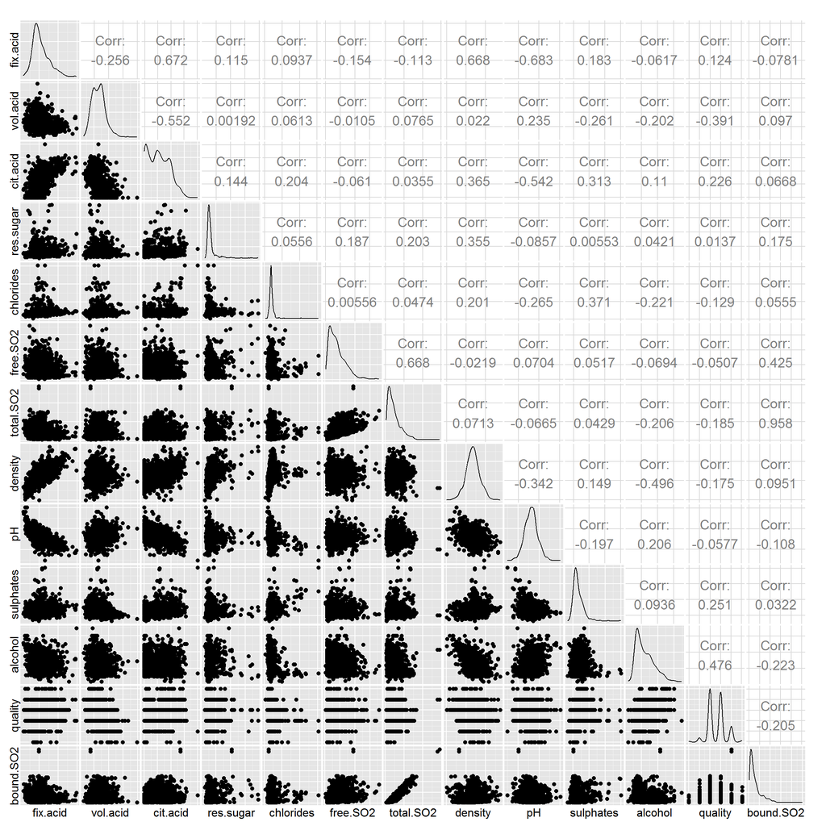

### Quality vs other variables

I want to explore the relationship between quality and several other variables: alcohol, volatile acidity, citric acid, sulphates and total sulfur dioxide.

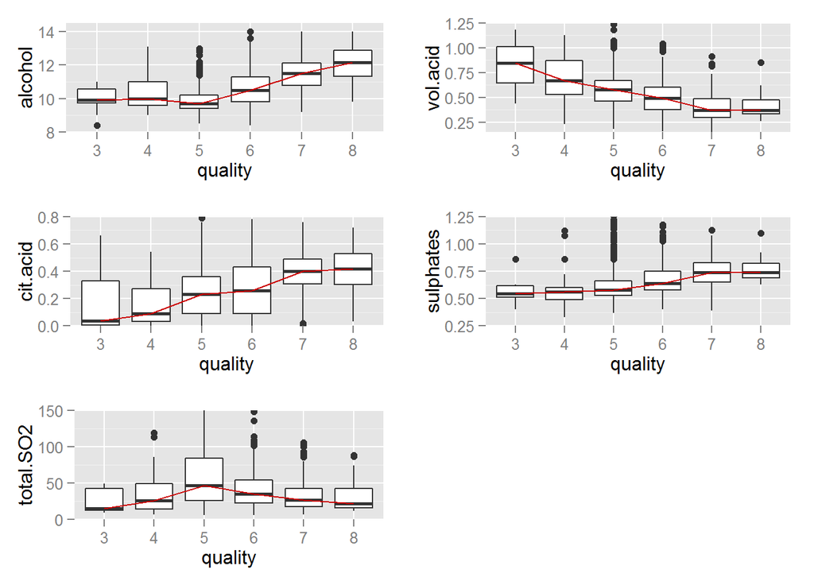

Alcohol has the highest correlation value (0.48) with quality and we can see that the median level of alcohol increases as the quality score of the wine increases. Conversley the median level of volatile acidity decreases as the quality score of wine goes up, and this is expected given the correlation value of -0.39. Generally the higher the median level of both citric acid (0.23) and sulphates (0.25), the higher the quality of the wine. The correlation between total sulfur dioxide (-0.19) and quality is less clear as a middle quality score of 5 or 6 have the highest median levels of total sulfur dioxide.

### Density vs other variables

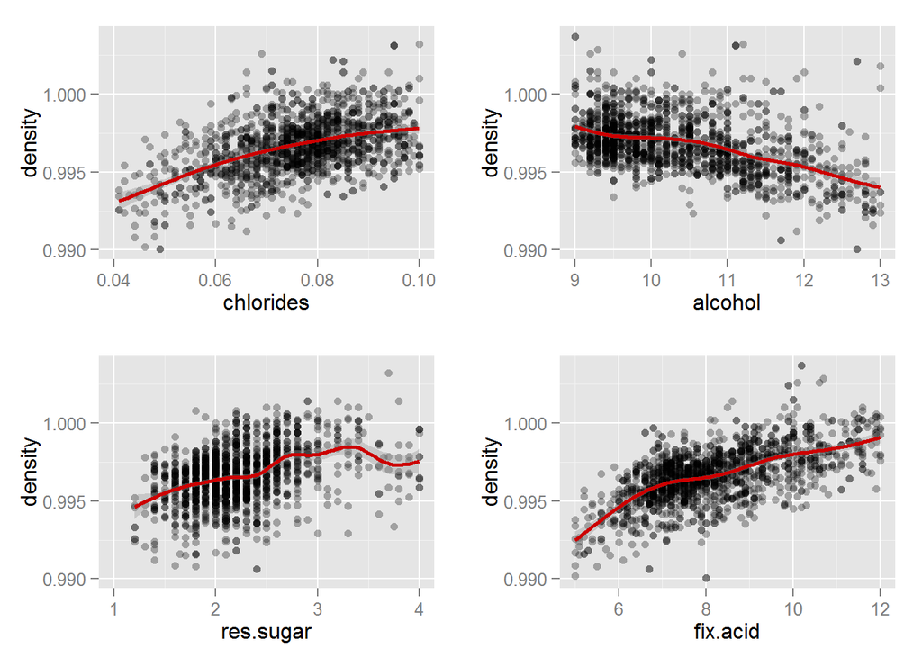

It is clear that there are several factors that affect the density of the wine. Increasing the amount of sugar (0.36), fixed acid (0.67) or chlorides/salt (0.20) increase the density of the wine. However incrasing the alcohol (-0.50) percentage of the wine decreases the density. This is expected as alcohol is less dense than water so by increasing the percent of alcohol you decrease the percent of water, decreasing the overall density.

### pH vs other variables

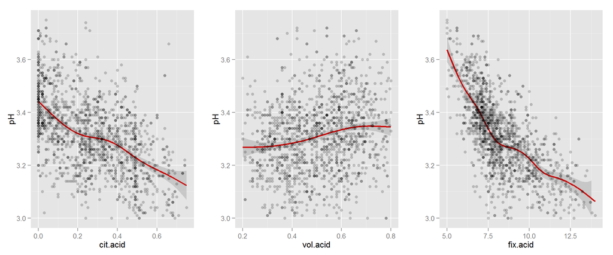

There is a clear negative relationship between citric acid (-0.54) and pH level as well as fixed acidity (-0.68) and pH level. This is expected as lower pH levels are linked to higher levels of acidity. There is a positive correlation between volatile acidity (0.23) and pH.

# Bivariate Analysis

### Talk about some of the relationships you observed in this part of the investigation. How did the feature(s) of interest vary with other features in the dataset?

Wine quality correlates positively most strongly with the percentage of alcohol. There is a positive correlation between both citric acid and sulphates with the quality of red wine.

As volatile acidity decreases the quality of wine increases. We also see a decrease in the variance of the volatile acidity in wines of higher quality.

### Did you observe any interesting relationships between the other features (not the main feature(s) of interest)?

The is a clear positive correlation between density and the variables fixed acidity, chloride levels and residual sugar level. There is a strong negative correlation between wine density and the alcohol level of the wine.

The pH level of a wine decreases as the levels of citric acid and fixed acid increase, however pH levels go up as the level of volatile acidity increase.

Whist investigating the relationship between the free sulfur dioxide levels and the quality score of the wine I noticed a very interesting relationship. They points on the chart show almost a normal distribution indicating that low levels of free sulfur dioxide are linked to both high and low quality wines, whereas higher levels of sulfur dioxide are linked to medium quality wines.

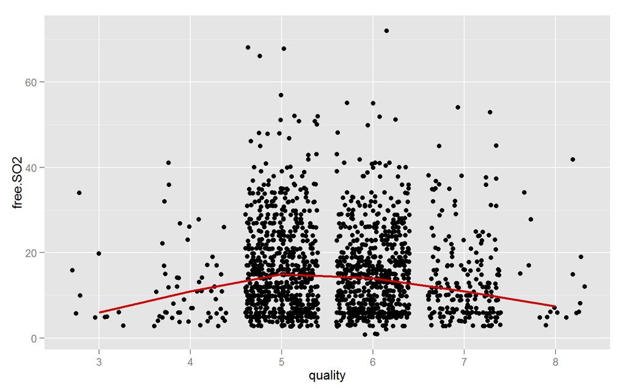

Looking more closely at the ggpairs correlations I noticed two interesting correlations with the level of residual sugar. A similar pattern was seen with both chlorides (0.06) and sulphates (0.01):

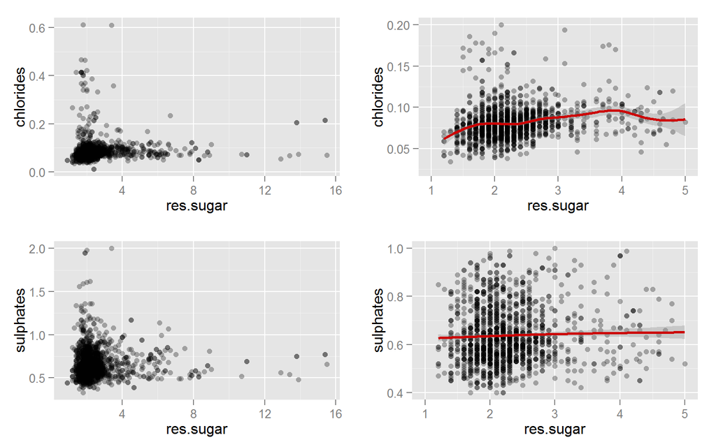

Both these charts display a large number of points at the lower left corner and then outliers at the top left and bottom right, but no points in the top right. After removing the outliers on both charts and plotting a regression line we can see that there is a slight positive correlation between the two sets of values which is in line with our correlation matrix.

After some research it appears that both chlorides and sulphates are a type of salt. The charts suggest that we do not observe wines with high levels of sugar and salt, wines with high salt (cholirdes or sulphates) have low levels of sugar (residual sugar), and wines with high sugar levels have low levels of salt.

### What was the strongest relationship you found?

The chemical property that has the strongest relationship with the quality score of red wine is the alcohol level of the wine. The higher quality wines have a higher alcohol percentage and we noticed a correlation of 0.476.

Overall the strongest relationship between two variables was a score of 0.96 between total sulfur dioxide levels and bound sulpfur dioxide levels. This is to be expected as total is a count of bound and free levels of sulfur dioxide. Aside from this the next strongest correlation with a score of -0.68 was between pH levels and fixed acidity.

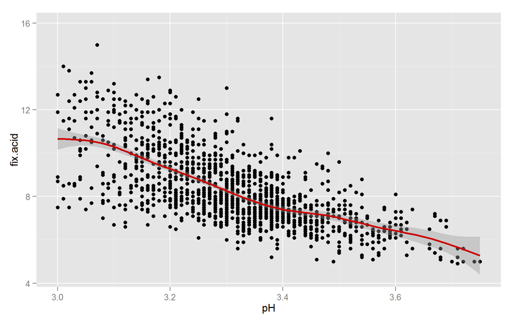

# Multivariate Plots Section

Having observed that alcohol levels have the strongest correlation with the output variable (quality score) I wanted to explore how other variables affected the quality of a red wine when compared with to alcohol levels. Using the multivariate plots it is much easier to see the distribution of quality scores across the plots:

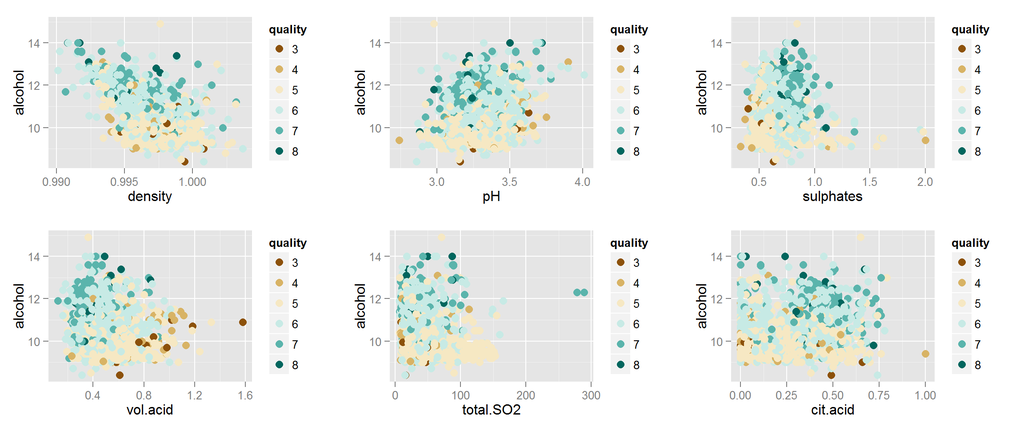